# Dissemination to Healthcare System Leaders - Rethinking Clinical Trials

## A Living Textbook of Pragmatic Clinical Trials

# Dissemination to Healthcare System Leaders

# Dissemination Approaches For Different Stakeholders

## Section 5

## Dissemination to Healthcare System Leaders

Contributors

### Practical Reporting Strategies for Study Teams

> “When planning research, by prospectively thinking about how findings will be translated to clinical practice, key considerations may be what clinicians will need to change their behavior and what resources the organization will require to permanently maintain (sustain) the intervention.” – Curtis et al. 2017

As described elsewhere in the Living Textbook, a key element of successful embedded pragmatic clinical trials (ePCTs) is [engagement with stakeholders](https://rethinkingclinicaltrials.org/chapters/engaging-stakeholders/stakeholder-engagement-throughout-the-pct-life-cycle/), early and often. The stakeholders who will be particularly interested in the results of your ePCT intervention—and who will be crucial to the adoption of your findings—include the [healthcare system leaders](https://rethinkingclinicaltrials.org/chapters/engaging-stakeholders/advice-from-healthcare-system-leadership/) responsible for making decisions about which interventions to implement and sustain. Ideally, ePCT study teams will establish ongoing, bidirectional health system partnerships throughout the lifecycle of the trial and will plan their intervention with “[implementation in mind](https://rethinkingclinicaltrials.org/chapters/design/designing-implementation-dissemination-mind-top/designing-with-implementation-and-dissemination-in-mind-introduction/).” Such planning includes considering how study results will be conveyed to the health system partners. Continuous engagement with partners can help ensure that the context for the intervention is well understood and that your partners will facilitate knowledge translation and support the intervention after the trial is completed.

Next we suggest a few practical strategies and tools for sharing study findings with healthcare system partners—beyond the usual [journal publications](https://rethinkingclinicaltrials.org/chapters/dissemination/dissemination-different-stakeholders/reporting/) and professional conferences. Study teams should tailor the message and medium to the needs and priorities of the health system. Make what you say clear and what you show visually appealing. Make your study results actionable, and engage with your health system partners to develop a customized sustainment plan.

#### 1. Plan for impact

From the time the proposal is written, and particularly at the start of funding, invest in relationships with healthcare system stakeholders such as administrators and executives in the C-suite (CEO, CIO, COO, etc.). Over time and with regular communication, study teams can learn the language of the leaders, how the health system functions, and what level of evidence decision-makers will use to justify their decisions. One outcome will be that health system leaders will learn the potential of your embedded intervention for improving quality and efficiency within their health system. For their part, leaders can enhance collaborations by effectively communicating their challenges and learning to frame problems in researchable terms (Alexander et al. 2007). Many embedded researchers use the research funding or seek supplemental funding to disseminate preliminary and summative findings.

Example activities for planning for impact:

- Identify why the study findings will matter to health system leaders, whether findings are positive or negative.
- Identify other partners, such as patient advocacy organizations, that could amplify the findings if successful.
- Assess the context for adopting and sustaining positive findings.
- Determine what study tools will be developed, including health system-, provider-, and patient-facing tools and materials.
- Establish a dissemination advisory panel and consider carefully who will serve on it.
- Set up a website portal for study materials, but be mindful about not launching the website until after study results are shared to prevent contamination of the study arms.

*Note:* It is important to disseminate findings even if the results are negative, as important learning and insight for future research can be gleaned from all results, including a hypothesized outcome that was not achieved.

When involving health system leadership in trial planning, there will be discussions of key comparators, outcomes, and the appropriateness and feasibility of the intervention. The Health Foundation (UK) has developed a template to help health researchers plan a communication strategy. Considerations include the context, key objectives, messaging, audience, communications channels, and additional resources.

*Excerpt from the Health Foundation’s communication strategy template*

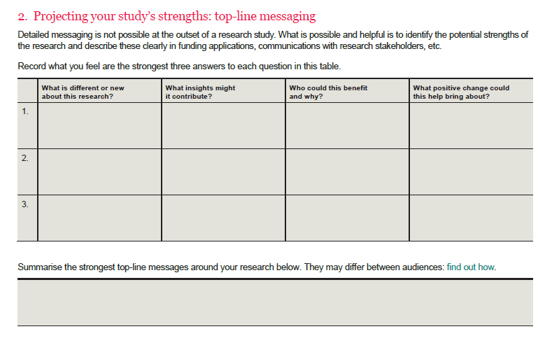

#### 2. Communicate findings in person

Prepare direct, in-person presentations (when possible) for your partners that synthesize your findings in an engaging format. Health system leaders prefer information on effectiveness over efficacy, evidence that is distilled, and results that are actionable (White et al. 2017). Explain how adopting the intervention could work in their health system context. Take the time to receive feedback from stakeholders on your findings, especially what needs to be implemented or de-implemented.

Example communication products:

- Tailored briefs, executive summaries, or fact sheets
- Multimedia slide show
- Animated video
- Interactive webinar that includes polling
- Workflow demo
- Role playing
- Educational session

#### 3. Provide leave-behind materials and tools

As an encouragement to adopt an intervention, study teams can leave their partner health systems with easy-to-use tools and other tangible resources. Consider devising solutions such as recommendations, clinical pathways, step-by-step instructions, and point-of-care algorithms (White et al. 2017). This will help indicate that materials are already created and there is less for the health system to provide at the time of implementation and sustainability.

Example resources:

- Intervention website
- Protocol toolkit
- Animated workflow
- Infographic or poster
- Summary sheet or FAQ
- Data visualization
- Decision flowchart
- Clinical encounter aid
- Training video
- Implementation guide

### Dissemination Case Studies

#### *REDUCE MRSA and ABATE Infection*

[figure not shown]

*Cover of Protocol Toolkit*

The REDUCE MRSA trial was a large, cluster-randomized pragmatic trial of 43 hospitals (74 adult ICUs) that demonstrated that universal bathing with chlorhexidine and universal nasal decolonization with mupirocin significantly reduced MRSA clinical cultures and all-cause bloodstream infections in adult ICUs. A related study, [ABATE Infection](https://rethinkingclinicaltrials.org/uh3-project-active-bathing-to-eliminate-abate-infection/), was an NIH Collaboratory Demonstration Project conducted in a non-ICU setting. Among the study team’s dissemination activities that supported practice change in the partner health system was a collaboration with the CDC and AHRQ to develop a [52-page protocol](https://www.ahrq.gov/hai/universal-icu-decolonization/index.html) for universal decolonization in the ICU (results from REDUCE MRSA) that provides “decision-making tools and a rationale to help hospital leaders understand the effectiveness of ICU decolonization with mupirocin and chlorhexidine gluconate (CHG) and determine whether this strategy represents the best course of action for their facility.” The document was designed for health system leaders to understand the study results and know how to decide to implement and then train staff in the intervention.

Read more about the value of [creating targeted tools](https://rethinkingclinicaltrials.org/chapters/dissemination/dissemination-implementation-top/creation-of-targeted-tools-2/) and the REDUCE MRSA case study illustrating how an embedded PCT planned for and delivered a successful dissemination strategy to their health system partners.

#### *STOP CRC*

The NIH Collaboratory Demonstration Project [Strategies and Opportunities to Stop Colorectal Cancer in Priority Populations (STOP CRC)](https://rethinkingclinicaltrials.org/demonstration-projects/uh3-project-strategies-and-opportunities-to-stop-colorectal-cancer-in-priority-populations-stop-crc/) was a cluster-randomized trial that tested a culturally tailored, healthcare system–based program to improve colorectal cancer screening rates in 26 federally qualified health center clinics in Oregon and California. The intervention involved embedding a tool in the electronic health record (EHR) to identify patients who were overdue for colorectal cancer screening, mailing a fecal immunochemical test (FIT) kit and reminder letter to eligible patients, and implementing a practice improvement process at participating clinics. Compared with clinics that practiced usual care, intervention clinics had a significantly higher proportion of participants who completed a FIT and any colorectal cancer screening. The improved screening rates occurred despite low and highly variable rates of implementation of the program.

STOP CRC dissemination activities included a [website](https://research.kpchr.org/Research/Our-People/Gloria-D-Coronado/mailedfit/Maile-FIT-Implementation-Guide) of resources, program materials, and an implementation guide describing the “Mailed FIT Program and how to orient a clinic to the program. Clinics that implement the STOP CRC program need to address technical, workflow, and policy questions before launching it. This guide is intended to address these questions.” This guide was based on lessons from a workshop on fundamental concepts of communications planning led by members of AcademyHealth’s communications team.

[figure not shown]

*STOP CRC Website*

### Communications Toolkits, Templates, and Resources

Various materials and approaches are available that can assist study teams with their communications planning with health system leaders. We discuss a few below.

[*Research Toolkit*](http://researchtoolkit.org.isomedia.net/disseminating-and-closing-research)

This toolkit provides resources “to help with the publication process, ideas for dissemination beyond publishing in a research journal, guidance for managing study data, and specific steps to facilitate the formal closure of a study.”

[*Health Foundation*](https://www.health.org.uk/publications/communicating-your-research-a-toolkit)

The Health Foundation (UK) provides a quick guide to help health researchers develop a communication strategy. Considerations include the context, key messaging and objectives, audience, communications channels, and additional resources.

[*Vanderbilt Dissemination Toolkit*](https://victr.vumc.org/dissemination-toolkit-resources/)

This website offers publicly available Dissemination Toolkits that are free to download and use. These toolkits contain guidelines, strategies, checklists, worksheets, templates, examples, and case studies for developing dissemination plans and products.

[*PCORI Dissemination and Implementation Framework and Toolkit*](https://www.mathematica.org/our-publications-and-findings/projects/pcori-dissemination-and-implementation-framework-and-toolkit)

This framework was developed by Mathematica, AcademyHealth, and Palladian Partners to provide information and tools for designing and implementing a robust dissemination strategy informed by multiple stakeholder groups.

*[Canadian Institutes of Health Research (CIHR): Knowledge Translation](https://cihr-irsc.gc.ca/e/29418.html#4.2)*

This website provides resources for knowledge translation, which is a dynamic and iterative process that includes “synthesis, dissemination, exchange, and ethically-sound application of knowledge to improve health.”

[*National Academy of Medicine (NAM)*](https://nam.edu/)

Two NAM discussion papers include strategies and examples for research dissemination within healthcare delivery settings:

- [Integrating Research into Health Care Systems: Executives’ Views](https://nam.edu/perspectives-2015-integrating-research-into-health-care-systems-executives-views/) (Johnson et al. 2015). Describes how health system executives (i.e., C-suite) think about the value and challenges of integrating effectiveness research knowledge generation as an essential element of a learning health system.
- [Generating Knowledge from Best Care: Advancing the Continuously Learning Health System](https://nam.edu/generating-knowledge-from-best-care-advancing-the-continuously-learning-health-system/) (Abraham et al. 2016). Among the recommendations for leaders of health systems engaged in embedded clinical research is to “define a course of action that would result from any plausible answer to a good question. For example, if the question involved the effectiveness of a new clinical strategy or approach to delivering care, leaders should anticipate how the program can be disseminated if it is effective, and should be willing to terminate it or modify it if not.”

[*Agency for Healthcare Research and Quality (AHRQ)*](https://effectivehealthcare.ahrq.gov/)

Two AHRQ methods papers from the Effective Health Care Program provide insights for sharing study findings with healthcare system leadership.

- [Understanding Health-Systems' Use of and Need for Evidence To Inform Decisionmaking](https://pubmed.ncbi.nlm.nih.gov/29611913/) (White et al. 2017)
- [A Framework for Conceptualizing Evidence Needs of Health Systems](https://pubmed.ncbi.nlm.nih.gov/29708677/) (Schoelles et al. 2017)

#### Other Approaches

Some researchers have found it helpful to work with different organizations to disseminate their results. For example, funders, nonprofits, accreditation and advisory groups such as Agency for Healthcare Research and Quality (AHRQ), National Quality Forum (NQF), Advisory Committee on Immunization Practices (ACIP), Institute for Healthcare Improvement (IHI), and Healthcare Infection Control Practices Advisory Committee (HICPAC). Other communication channels include professional societies, conferences, magazines, academic journals (e.g., [Health Affairs](http://www.healthaffairs.org/)), and through peers and clinicians. There are an increasing number of repositories for evidence-based practices, as well as collections of systematic reviews and community and clinical guidelines.

REFERENCES

Abraham. Generating Knowledge from Best Care: Advancing the Continuously Learning Health System. NAM Perspectives. Discussion Paper, National Academy of Medicine, Washington, DC. doi: 10.31478/201609b. Available at: https://nam.edu/generating-knowledge-from-best-care-advancing-the-continuously-learning-health-system/.

Alexander JA, Hearld LR, Jiang HJ, Fraser I. 2007. Increasing the relevance of research to health care managers: hospital CEO imperatives for improving quality and lowering costs. Health Care Manage Rev. 32:150-159. doi:10.1097/01.HMR.0000267792.09686.e3. PMID: 17438398.

Curtis K, Fry M, Shaban RZ, Considine J. 2017. Translating research findings to clinical nursing practice. J Clin Nurs. 26:862-872. doi:10.1111/jocn.13586. PMID: 27649522.

Johnson K, Grossmann C, Anau J, et al. Integrating Research into Health Care Systems: Executives’ Views. Available at: https://nam.edu/perspectives-2015-integrating-research-into-health-care-systems-executives-views/.

Schoelles K, Umscheid CA, Lin JS, et al. AHRQ Methods for Effective Health Care. A Framework for Conceptualizing Evidence Needs of Health Systems. Rockville (MD): Agency for Healthcare Research and Quality (US), 2017.

White CM, Sanders Schmidler GD, Butler M, et al. AHRQ Methods for Effective Health Care. Understanding Health-Systems' Use of and Need for Evidence To Inform Decisionmaking. Rockville (MD): Agency for Healthcare Research and Quality (US), 2017.

Version History

February 25, 2021: Updated the section title (change made by D. Seils).

February 3, 2021: Updated with new strategies and resources (changes made by L. Wing).

December 11, 2018: Updated as part of the annual review process, modified table and added text (changes made by K. Staman).

Published August 25, 2017